# **Topic: Stroke Prediction Project**

# **Overview**

**Dataset:**

The selected dataset is about Stroke, this dataset is used to predict whether a patient is likely to get stroke based on the input parameters like gender, age, various diseases, and smoking status. The data consists of 5110 rows and each row in the data provides relevant information about the patient. Dataset link:https://www.kaggle.com/datasets/fedesoriano/stroke-prediction-dataset

**Attributes:**

1) id, 2) gender, 3) age, 4) hypertension, 5) heart disease, 6) ever married, 7) work type, 8) Residence type, 9) glucose level, 10) BMI, 11) smoking status, 12) stroke.

**Problem:**

Stroke is like a heart attack, except it occurs in the blood vessels of the brain. Clots can form in the brain's blood vessels, in blood vessels leading to the brain, or even in blood vessels elsewhere in the body and then travel to the brain. These clots block blood flow to the brain's cells. There is conflict between heart attack and stroke.

**Motivation:**

Our objective is to analyze the relation between attributes and Stroke and build Machine learning model to detect stroke cases.

# **The Machine learning Algorithms**

**We selected two machine learning modes:**

**• Logistic regression:** is a supervised learning method for classifying data into discrete outcomes. The logistic regression model passes the outcome of a linear function of features through a sigmoid function to calculate the probability of an occurrence. The model then maps the probability to binary outcomes.

**• Random forest:** is a supervised learning algorithm. The "forest" it builds, is an ensemble of decision trees, usually trained with the “bagging” method. The general idea of the bagging method is that a combination of learning models increases the overall result.

# **The built/produced Model**

**Cleaning and pre-processing steps:**

We started by checking null values and BMI column have 201 empty values, so we filled the null values with median value of BMI. Also, we deleted unneeded column (id).

Machine learning models can't deal with text, so we used Label Encoder that converts classes columns to numbers, every class have certain number. Because, the dataset is unbalance dataset, we used Smote to oversample the minority class (Apply SMOTE to training data only).

**About the data splitting:** We split the data into 25% test set and 75% training set.

**Implementation(Building the predictive model (Steps and Procedures)):**

Now the data is cleaned, pre-processed and spitted so, we can train the selected models (Logistic regression, Random Forest) on training data, then used test data in prediction and getting accuracy, and compare the accuracy of both models. because accuracy is not sufficient, we used confusion matrix to know the values of true positive, true negative, false positive and false negative.

# **The Result Discussion:**

This imbalanced dataset has 4.9% of data in the stroke class, so in data splitting, we made sure that the training and testing data included the stroke class. After training the models, the accuracy of Logistic Regression is 76%, and the accuracy of Random Forest is 89%.

```python
import numpy as np
import pandas as pd
import seaborn as sns
import matplotlib.pyplot as plt
from sklearn.model_selection import train_test_split
from imblearn.over_sampling import SMOTE
from sklearn.metrics import accuracy_score,confusion_matrix,f1_score
from sklearn.preprocessing import StandardScaler
scaler= StandardScaler()
from sklearn.linear_model import LogisticRegression
from sklearn.ensemble import RandomForestClassifier
from sklearn.metrics import classification_report
from sklearn.metrics import accuracy_score, confusion_matrix, classification_report, roc_auc_score
import warnings
warnings.filterwarnings('ignore')
```

# Reading Data

```python
df = pd.read_csv('/content/healthcare-dataset-stroke-data.csv')
df.head()
```

|  | id | gender | age | hypertension | heart_disease | ever_married | work_type | Residence_type | avg_glucose_level | bmi | smoking_status | stroke |
| --- | --- | --- | --- | --- | --- | --- | --- | --- | --- | --- | --- | --- |
| 0 | 9046 | Male | 67.0 | 0 | 1 | Yes | Private | Urban | 228.69 | 36.6 | formerly smoked | 1 |
| 1 | 51676 | Female | 61.0 | 0 | 0 | Yes | Self-employed | Rural | 202.21 | NaN | never smoked | 1 |
| 2 | 31112 | Male | 80.0 | 0 | 1 | Yes | Private | Rural | 105.92 | 32.5 | never smoked | 1 |
| 3 | 60182 | Female | 49.0 | 0 | 0 | Yes | Private | Urban | 171.23 | 34.4 | smokes | 1 |
| 4 | 1665 | Female | 79.0 | 1 | 0 | Yes | Self-employed | Rural | 174.12 | 24.0 | never smoked | 1 |

```python
len(df)
```

```
5110
```

```python
df.info()
```

```
<class 'pandas.core.frame.DataFrame'>
RangeIndex: 5110 entries, 0 to 5109
Data columns (total 12 columns):
 #   Column             Non-Null Count  Dtype
---  ------             --------------  -----
 0   id                 5110 non-null   int64
 1   gender             5110 non-null   object
 2   age                5110 non-null   float64
 3   hypertension       5110 non-null   int64
 4   heart_disease      5110 non-null   int64
 5   ever_married       5110 non-null   object
 6   work_type          5110 non-null   object
 7   Residence_type     5110 non-null   object
 8   avg_glucose_level  5110 non-null   float64
 9   bmi                4909 non-null   float64
 10  smoking_status     5110 non-null   object
 11  stroke             5110 non-null   int64
dtypes: float64(3), int64(4), object(5)
memory usage: 479.2+ KB
```

# Data Cleaning

```python
#drop unneeded column
df.drop('id',axis = 1,inplace=True)
```

```python
#check null values
df.isna().sum()
```

|  | 0 |
| --- | --- |
| gender | 0 |
| age | 0 |
| hypertension | 0 |
| heart_disease | 0 |
| ever_married | 0 |
| work_type | 0 |
| Residence_type | 0 |
| avg_glucose_level | 0 |
| bmi | 201 |
| smoking_status | 0 |
| stroke | 0 |

**dtype:** int64

```python
# As we can see there are nulls in BMI feature, So we will fill the null values with median value of BMI
df.bmi = df.bmi.fillna(df.bmi.median())
```

```python
#check null values again
df.isna().sum()
```

|  | 0 |
| --- | --- |
| gender | 0 |
| age | 0 |
| hypertension | 0 |
| heart_disease | 0 |
| ever_married | 0 |
| work_type | 0 |
| Residence_type | 0 |
| avg_glucose_level | 0 |
| bmi | 0 |
| smoking_status | 0 |
| stroke | 0 |

**dtype:** int64

# Data Analysis

> **Distribution of Data**

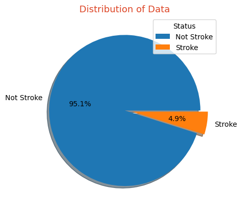

```python
plt.title('Distribution of Data', size = 13, color = '#dd4526')
plt.pie(x=df['stroke'].value_counts(), labels=df['stroke'].value_counts().index.map({0:'Not Stroke', 1:'Stroke'}),startangle=360, autopct='%1.1f%%',explode=(0,0.1),shadow=True)
plt.legend(title='Status',loc = 'upper right')
plt.show()
```

The above plot illustrate that the data is imbalace where most of data are non-stroke and about 4.9% stroke

> **Relation Between Gender and Stroke**

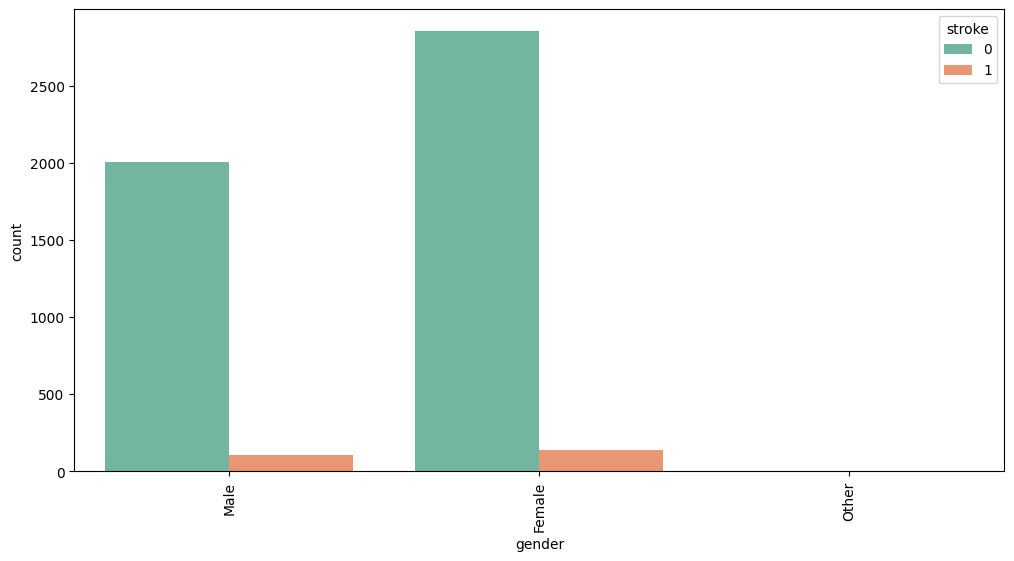

```python
plt.figure(figsize=(12,6))
plt.xticks(rotation = 90)
sns.countplot(x='gender', hue='stroke', data=df, palette='Set2') # Specify data and x
plt.show()
```

We found that females have more rows in data regarding in stroke or non-stroke classes

> **Relation Between Smoking and Stroke**

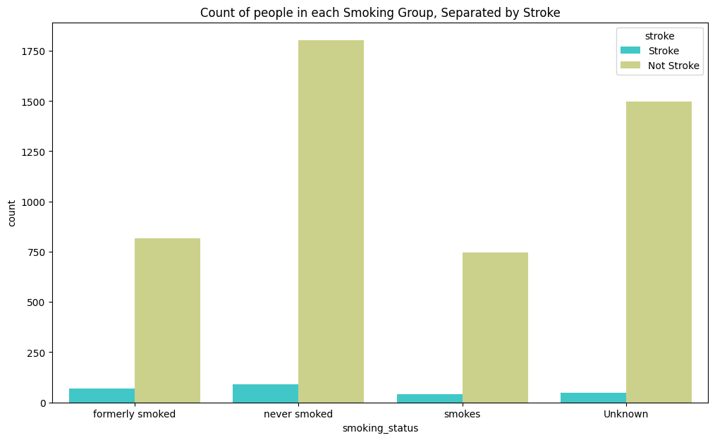

```python
plt.figure(figsize=(12,7))

ax=sns.countplot(x='smoking_status',data=df, palette='rainbow',hue=df['stroke'].map({0:'Not Stroke', 1:'Stroke'}))
plt.title("Count of people in each Smoking Group, Separated by Stroke")
plt.show()
```

# Now, we will analyze only stroke data

```python
#filter the data to get only stroke data
strock_df=df[df.stroke==1]
```

> **Distribution of Stroke Based on Age, Glucose**

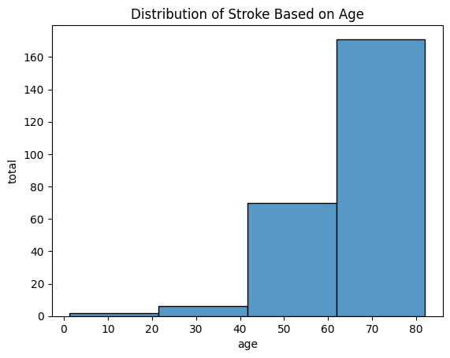

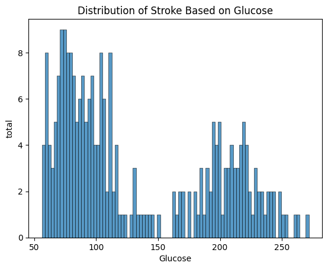

```python
sns.histplot(strock_df['age'], bins=4)
plt.xlabel('age')
plt.ylabel('total')
plt.title('Distribution of Stroke Based on Age')
plt.show()

sns.histplot(strock_df['avg_glucose_level'],bins=88)
plt.xlabel('Glucose')
plt.ylabel('total')
plt.title('Distribution of Stroke Based on Glucose')
plt.show()
```

> **Distribution of Stroke Based on smoking_status**

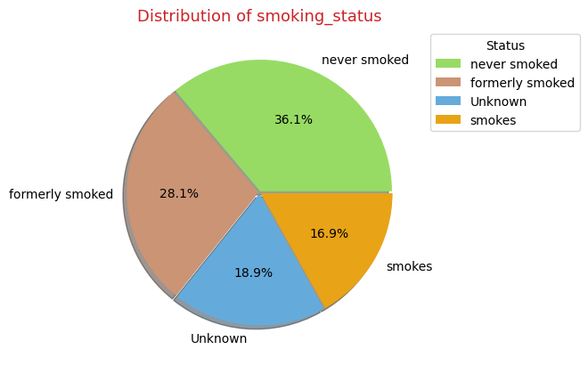

```python
plt.title('Distribution of smoking_status', size = 13, color = '#cc2226')
colors = ['#97DB64', '#CA9475', '#64ABDB', '#e8a317', '#4ss552']
plt.pie(x=strock_df['smoking_status'].value_counts() ,labels=strock_df['smoking_status'].value_counts().index,startangle=360, autopct='%1.1f%%',explode=(0.01,0.01,0.01,0.01),shadow=True,colors=colors)
plt.legend(title='Status',bbox_to_anchor=(1,1))
plt.show()
```

The above plot shows the Distribution of smoking_status for stroke data, and it seems that smoking_status doesn't tell us anything confounding about stroke-positive individuals but it may affect with other attributes.

> **Relation between avg_glucose_level and other features for stroke cases**

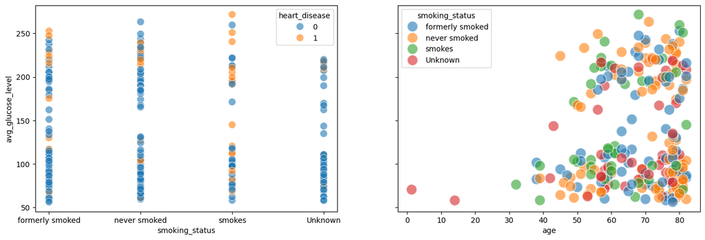

```python
# Create subplots
f, (ax1, ax2) = plt.subplots(1, 2, sharey=True, figsize=(16,5))

sns.scatterplot(data=strock_df, y='avg_glucose_level', x='smoking_status',
                hue='heart_disease', s=100, alpha=0.6, ax=ax1)

sns.scatterplot(data=strock_df, y='avg_glucose_level', x='age',
                hue='smoking_status', s=200, alpha=0.6, ax=ax2)


plt.show()
```

> **Relation between BMI, age and gender for stroke cases**

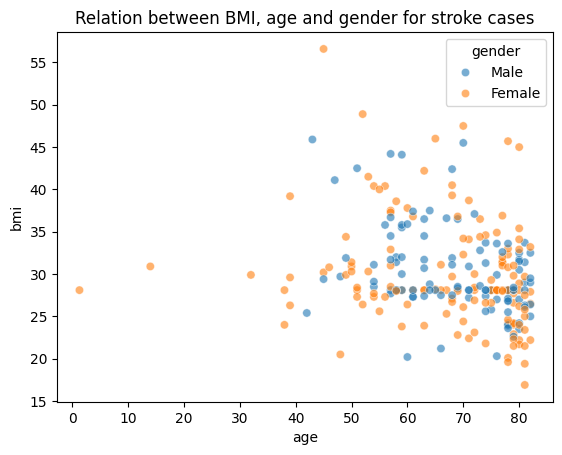

```python
sns.scatterplot(data=strock_df, x='age', y='bmi', hue='gender', alpha=0.6)
plt.title('Relation between BMI, age and gender for stroke cases')
plt.show()
```

# Pre-processing

```python
data_pre = df.copy()

#LabelEncoder converts classes text to numbers , every class have certain number
from sklearn.preprocessing import LabelEncoder
le = LabelEncoder()
data_pre['gender'] = le.fit_transform(data_pre['gender'])
data_pre['ever_married'] = le.fit_transform(data_pre['ever_married'])
data_pre['work_type'] = le.fit_transform(data_pre['work_type'])
data_pre['Residence_type'] = le.fit_transform(data_pre['Residence_type'])
data_pre['smoking_status'] = le.fit_transform(data_pre['smoking_status'])
data_pre.head()
```

|  | gender | age | hypertension | heart_disease | ever_married | work_type | Residence_type | avg_glucose_level | bmi | smoking_status | stroke |
| --- | --- | --- | --- | --- | --- | --- | --- | --- | --- | --- | --- |
| 0 | 1 | 67.0 | 0 | 1 | 1 | 2 | 1 | 228.69 | 36.6 | 1 | 1 |
| 1 | 0 | 61.0 | 0 | 0 | 1 | 3 | 0 | 202.21 | 28.1 | 2 | 1 |
| 2 | 1 | 80.0 | 0 | 1 | 1 | 2 | 0 | 105.92 | 32.5 | 2 | 1 |
| 3 | 0 | 49.0 | 0 | 0 | 1 | 2 | 1 | 171.23 | 34.4 | 3 | 1 |
| 4 | 0 | 79.0 | 1 | 0 | 1 | 3 | 0 | 174.12 | 24.0 | 2 | 1 |

# Spliting Data

```python
# define x ,y for model
x= data_pre.drop(['stroke'],axis=1)
y= data_pre['stroke']
```

```python
#split data to train and test
x_train,x_test,y_train,y_test = train_test_split(x,y,test_size=0.25,random_state = 2021,stratify=y)
```

```python
# finally applying SMOTE to resample the data by increase number of stroke rows
sm = SMOTE()
# Apply SMOTE to training data only
x_train, y_train = sm.fit_resample(x_train,y_train)
```

# Building Model

```python
#Scaling integer columns
cols=['age','bmi','avg_glucose_level']
x_train[cols] = scaler.fit_transform(x_train[cols])
x_test[cols] = scaler.transform(x_test[cols])
```

```python
# Apply Logistic Regression
lr = LogisticRegression(solver='newton-cg', penalty='l2')
lr.fit(x_train, y_train)
```

```
LogisticRegression(solver='newton-cg')
```

```python
# Predictions
lr_pred = lr.predict(x_test)
lr_pred_proba = lr.predict_proba(x_test)[:, 1]
```

```python
# Calculate accuracy
lr_acc = accuracy_score(y_test, lr_pred)
print(f"Accuracy: {lr_acc:.4f}")
```

```
Accuracy: 0.7645
```

```python
# Compute Confusion Matrix
matrix = confusion_matrix(y_test, lr_pred)
print("Confusion Matrix:\n", matrix)
```

```
Confusion Matrix:
 [[933 283]
 [ 18  44]]
```

```python
# Classification Report
print("Classification Report:\n", classification_report(y_test, lr_pred))
```

```
Classification Report:
               precision    recall  f1-score   support

           0       0.98      0.77      0.86      1216
           1       0.13      0.71      0.23        62

    accuracy                           0.76      1278
   macro avg       0.56      0.74      0.54      1278
weighted avg       0.94      0.76      0.83      1278
```

```python
# Compute ROC-AUC Score
roc_auc = roc_auc_score(y_test, lr_pred_proba)
print(f"ROC-AUC Score: {roc_auc:.4f}")
```

```
ROC-AUC Score: 0.7959
```

```python
# Apply RandomForestClassifier
rf = RandomForestClassifier(criterion='gini', n_estimators=50, random_state=1)
rf.fit(x_train, y_train)
```

```
RandomForestClassifier(n_estimators=50, random_state=1)
```

```python
# Predictions
rf_pred = rf.predict(x_test)
rf_pred_proba = rf.predict_proba(x_test)[:, 1]
```

```python
# Calculate accuracy
rf_acc = accuracy_score(y_test, rf_pred)
print(f"Accuracy: {rf_acc:.4f}")
```

```
Accuracy: 0.8928
```

```python
# Compute Confusion Matrix
matrix = confusion_matrix(y_test, rf_pred)
print("Confusion Matrix:\n", matrix)
```

```
Confusion Matrix:
 [[1124   92]
 [  45   17]]
```

```python
# Classification Report
print("Classification Report:\n", classification_report(y_test, rf_pred))
```

```
Classification Report:
               precision    recall  f1-score   support

           0       0.96      0.92      0.94      1216
           1       0.16      0.27      0.20        62

    accuracy                           0.89      1278
   macro avg       0.56      0.60      0.57      1278
weighted avg       0.92      0.89      0.91      1278
```

```python
# Compute ROC-AUC Score
roc_auc = roc_auc_score(y_test, rf_pred_proba)
print(f"ROC-AUC Score: {roc_auc:.4f}")
```

```
ROC-AUC Score: 0.8015
```

After cleaning, preprocced the data and building two models

- LogisticRegression have 76% accuracy
- RandomForestClassifier have 89% accuracy